# The Split-Apply-Combine Strategy for Data Analysis

### Tahana Akram & Oliver Reece - ADC-405-S26 - Lawrence University

# Introduction

Data analysis rarely involves a single operation on an entire dataset. More often we need to ask questions like: *How did each baseball player’s performance change over their career? How does ozone vary by location and season?* These questions share a common structure. Break data into groups, do something to each group, and collect the results.

This recurring pattern is what Hadley Wickham (2011) formalized as the **split-apply-combine strategy**, and it is the foundation of the `plyr` package for R.

# The Three Steps

**1. Split** — Divide your dataset into meaningful subsets based on one or more grouping variables. For example, split a baseball dataset by player ID so each player’s records are handled separately. Subsets can be rows of a data frame, slices of an array, or elements of a list.

**2. Apply** — Run a function on each subset *completely independently*. This could be something simple like computing a mean, or something complex like fitting a linear regression model. Because each piece is independent, order does not matter and results are reproducible.

**3. Combine** — Collect all individual results and reassemble them into a single coherent output — a data frame, array, or list depending on what you need.

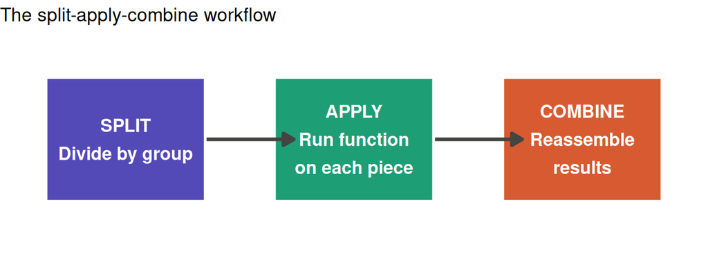

> *“Just recognizing the split-apply-combine strategy when it occurs is useful, because it allows you to see the similarity between problems that previously might have appeared unconnected.”* — Wickham (2011)

# Why plyr? Motivation

Before `plyr`, applying a function to every group in a dataset meant writing verbose for-loops full of bookkeeping code that buried the actual computation. The example below fits a model to every location in a 24×24 ozone grid, compare what base R requires versus `plyr`:

```
# Base R — 10 lines of bookkeeping
models <- as.list(rep(NA, 24 * 24))
dim(models) <- c(24, 24)
deseas <- array(NA, c(24, 24, 72))
for (i in seq_len(24)) {
  for (j in seq_len(24)) {
    mod <- deseasf(ozone[i, j, ])
    models[[i, j]] <- mod
    deseas[i, j, ] <- resid(mod)
  }
}

# plyr — 2 lines, same result
models <- aaply(ozone, 1:2, deseasf)
deseas <- aaply(models, 1:2, resid)
```

`plyr` eliminates hard-coded dimensions, removes the need to pre-allocate output structures, and makes the intent of the computation immediately clear. The function `deseasf` just does its job and `plyr` handles everything else.

# The plyr Function Family

Every `plyr` function is named **[input][output]ply** ,learn 3 input types and 3 output types and the whole family makes sense. Input and output can each be an **a**rray, **d**ata frame, or **l**ist. A fourth output type **_** discards results, useful for side effects like saving plots.

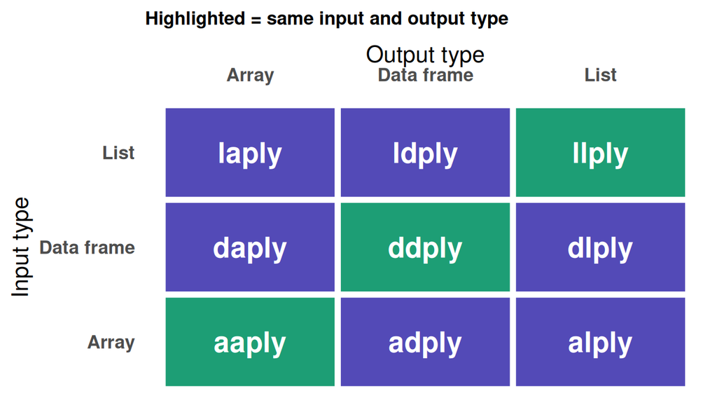

All functions share the same three arguments: `.data` (what to split), `.variables` or `.margins` (how to split), and `.fun` (what to apply to each piece). The dot prefix prevents name clashes with your own function’s arguments.

# Key Limitations

`plyr` makes one strong assumption that must always be respected: **each piece of data is processed independently and only once**. This means there are important cases where `plyr` is simply not the right tool:

- **Running averages or moving windows** — each calculation depends on neighboring values, so pieces are not truly independent
- **Dynamic simulations** — the output of step N feeds directly into step N+1, meaning order matters and independence is broken
- **Very large datasets** — `plyr` prioritizes code clarity over raw speed; for maximum performance, recoding key steps in C or using `data.table` may be necessary
- **Overlapping data windows** — pieces must not share data with each other for `plyr` to work correctly

> *“Note that plyr makes the strong assumption that each piece of data will be processed only once and independently of all other pieces.”* — Wickham (2011)

For these situations, a traditional for-loop is still the most appropriate tool. The goal of `plyr` is not to replace loops entirely but to replace loops **where the split-apply-combine pattern genuinely applies**.

# Helper Functions

`plyr` ships with several helper functions that make common tasks much cleaner and more robust:

**`splat(f)`** — converts a function that takes multiple named arguments into one that accepts a single data frame. Extremely useful when your function’s argument names match column names.

```
hp_per_cyl <- function(hp, cyl, ...) hp / cyl
ddply(mtcars, .(round(wt)), splat(hp_per_cyl))
```

**`each(f, g)`** — runs multiple functions on the same input and returns a named vector. Great for computing several summary statistics at once without writing wrapper functions.

**`colwise(f)`** — applies a function column-by-column across an entire data frame and returns a data frame. The `.if` argument restricts it to only numeric or factor columns. You can use colwise(function)(data) for every column or numcolwise(function)(data) or only numeric columns.

**`failwith(default, f)`** — returns a default value such as `NA` instead of stopping with an error when `f` fails. Essential when fitting many models where some subsets may be too small or poorly conditioned.

**`.progress = "text"`** — displays a live progress bar showing estimated time remaining. Particularly useful for long-running operations involving hundreds or thousands of subsets.

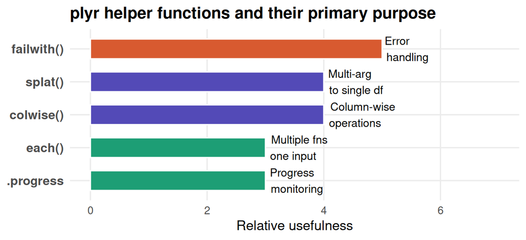

# The 4 Step Process

1. *Start Small*. Slice out a portion (subset) of the data to work on.
2. By hand, write out the problem and try to solve it.
3. Now take your hand-written solution and make it a reusable function.
4. Make the function autonomous using `plyr` functions. Run this function where needed, then stitch everything back together at the end.

Using these steps, Wickham proceeds to walk us through 2 case studies:

**Baseball Case Study**: He splits a data frame of career records by player ID, fits a linear model to each subset, and combines the resulting slopes, intercepts, and $R^2$ values back into a single data frame.

**Ozone Layer Case Study**: He slices a 3D array along its spatial coordinates, applies a linear model to each location’s time series, and puts the cleaned residuals back together into matching 3D and data frame formats.

# Reducing Cognitive Impedence

One of the main points of this article is that `plyr` is meant to help reduce human effort. `plyr` achieves this in a couple ways. Firstly, it keeps all labels and column/row names throughout the cleaning process such that when you connect everything back together, the labels are kept from the original data. This is not the case in base R. Furthermore, the input structure gets mapped directly to the output, meaning that you can switch back and forth between types like arrays, lists, and dataframes.

# `plyr` Performance Advantages

Alongside being more efficient for the user, `plyr` also has some hidden benefits. Below is a lollypop graph intending to visualise one of the most important ones: parallelisation.

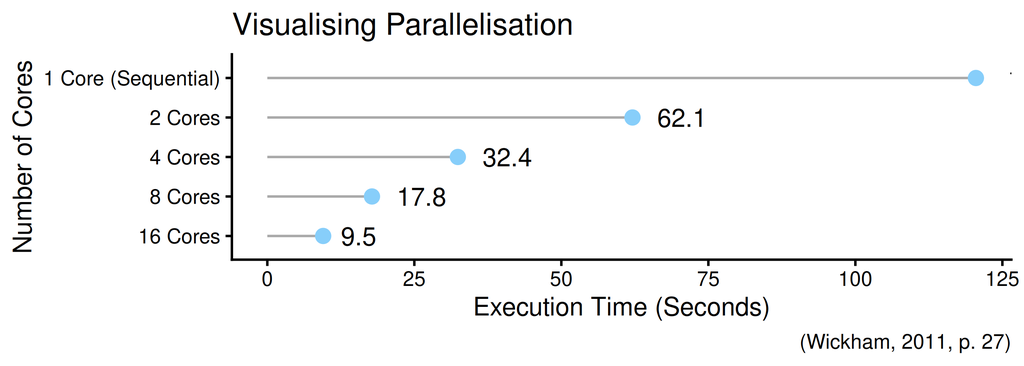

# Pre and Post Cleaned Data Example

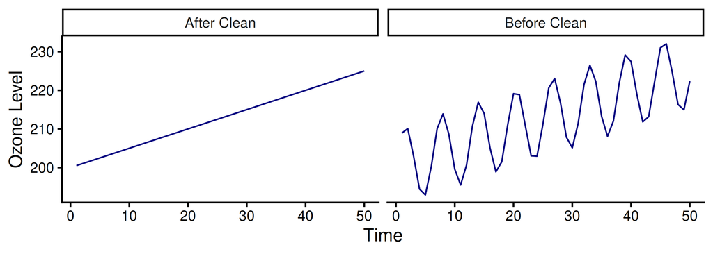